# Football_Win

Tarun Reddy Aleti

February 29, 2016

### Executive Summary

- The data set at hand covers all the “Serie A” football matches for the last 8 years of Italian Football League.
- Our goal is to predict the final result, having at your disposal the odds of various bookmakers.
- Need to use 6 years of data and predict the result for next 2 years.
- Best model is the one which predicts accurately more often.
- The dataset for the model can be downloaded from [train](https://inclass.kaggle.com/c/football-data-challenge/download/train.csv), [test](https://inclass.kaggle.com/c/football-data-challenge/download/test.csv)

#### Required Packages

Following packages are required for the code to run efficiently.

```r
library(MASS)
library(rjson)
library(plyr)
library(knitr)
library(caret)
library(fmsb)
library(e1071)
library(randomForest)
library(caretEnsemble)
library(ROCR)
library(ineq)
library(zipcode)
library(sqldf)
library(ggplot2)
library(lubridate)
library(psych)
```

#### Preliminary Analysis

For the code to execute, all the datasets should be in the R working directory. The datasets are in .csv format.

```r
set.seed(1)
data <- read.csv("train.csv", header = TRUE, stringsAsFactors = FALSE)
```

- The data set under consideration has a total of **1520** rows and **21** independent variables. Our dependent variable is *FTR (Full Time Result)* and is a categorical variable, wherein **A** indicates that Away team won, **H** indicates that home team won and **D** indicates that result was a draw
- Independent Variables are as follows
  1. *Date*: Indicates when the match was played
     - Can extract Weekday/Weekend, DayofWeek and Month information
  2. *HomeTeam*: Name of Home Team in the match
     - There are 27 different teams. We might need to create dummy variables for them.
     - The team names are Sampdoria, Verona, Cagliari, Inter, Lazio, Livorno, Napoli, Parma, Torino, Fiorentina, Chievo, Juventus, Atalanta, Bologna, Catania, Genoa, Milan, Roma, Sassuolo, Udinese, Palermo, Lecce, Reggina, Siena, Bari, Cesena, Brescia.
  3. *AwayTeam*: Name of Away Team in the match
     - There are 27 different teams. We might need to create dummy variables for them.
     - The team names are Juventus, Milan, Atalanta, Genoa, Udinese, Roma, Bologna, Chievo, Sassuolo, Catania, Napoli, Lazio, Torino, Sampdoria, Inter, Fiorentina, Cagliari, Verona, Livorno, Parma, Palermo, Siena, Reggina, Lecce, Bari, Cesena, Brescia.
     - There are same number of Home Teams as Away Teams
  4. *B365H*: Bet365 home win odds
  5. *B365D*: Bet365 draw odds
6. *B365A*: Bet365 away win odds
7. *BWH*: Bet&Win home win odds
8. *BWD*: Bet&Win draw odds
9. *BWA*: Bet&Win away win odds
10. *IWH*: Interwetten home win odds
11. *IWD*: Interwetten draw odds
12. *IWA*: Interwetten away win odds
13. *LBH*: Ladbrokes home win odds
14. *LBD*: Ladbrokes draw odds
15. *LBA*: Ladbrokes away win odds
16. *VCH*: VC Bet home win odds
17. *VCD*: VC Bet draw odds
18. *VCA*: VC Bet away win odds
19. *WHH*: William Hill home win odds
20. *WHD*: William Hill draw odds
21. *WHA*: William Hill away win odds

### Exploratory Data Analysis

1. *Frequency of Results*:

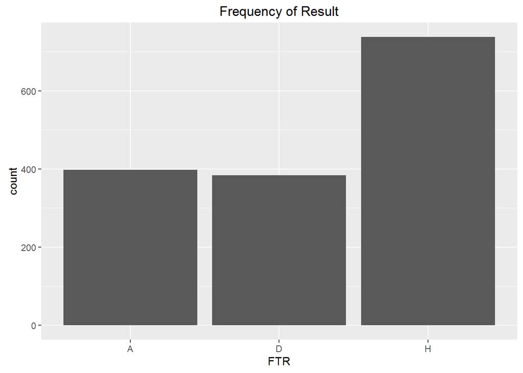

```r
ggplot(data, aes(FTR)) + geom_bar() + ggtitle('Frequency of Result')
```

Home team is more likely to win compare to Away Team or Draw Result. We can use Home Team as our Reference in Analysis

2. Frequency of Games played by Teams at Home:

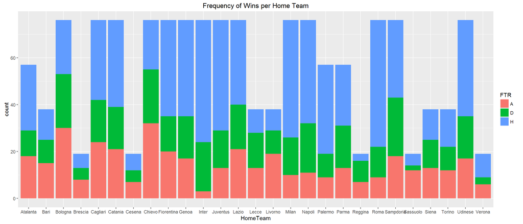

```r
ggplot(data, aes(HomeTeam, fill = FTR)) + geom_bar() + ggtitle('Frequency of Wins per Home Team')
```

3. Frequency of Games played by Teams Away:

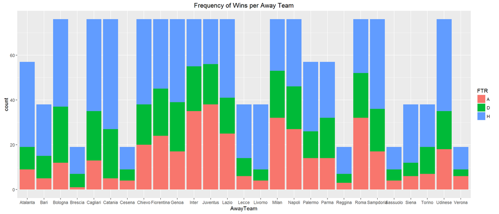

```r
ggplot(data, aes(AwayTeam, fill = FTR)) + geom_bar() + ggtitle('Frequency of Wins per Away Team')
```

4. Average Ratings per Result type for Home Team

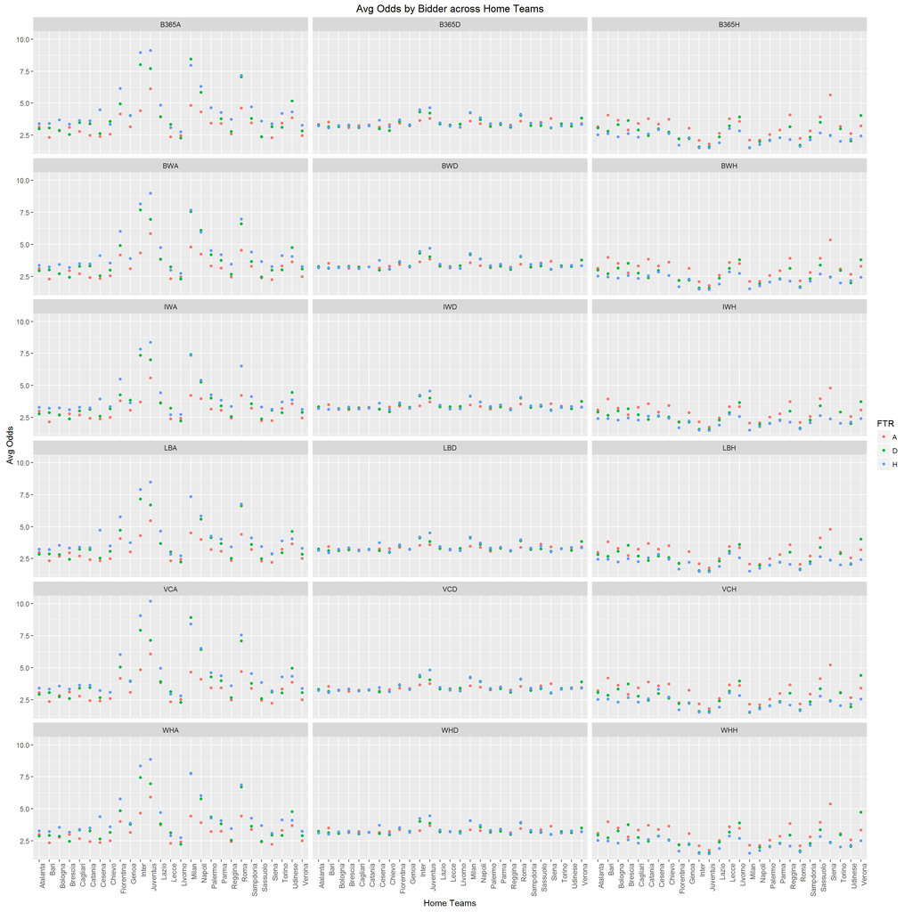

```r
query <- paste("SELECT ", paste('avg(', colnames(data)[6:23], '),', collapse = ""), " HomeTeam, FTR ",
               "FROM data
                GROUP BY HomeTeam, FTR", sep = "")
avg_data <- sqldf(query)
colnames(avg_data) <- c(paste('avg', colnames(data)[6:23], sep = "_"), "HomeTeam", "FTR")
l_avg_data <- alply(avg_data[ ,-c(19, 20)], 2, function(x){
                                                 y <- cbind(x, avg_data[ ,c(19, 20)])
                                                 colnames(y)[1] <- "Avg_Odds"
                                                 return(y)})
n_avg_data <- ldply(l_avg_data, function(x){x})
colnames(n_avg_data)[1] <- "Bid"
n_avg_data[ ,1] <- gsub("avg_", "", n_avg_data[ ,1])
ggplot(n_avg_data, aes(x = HomeTeam, y = Avg_Odds, colour = FTR)) + facet_wrap( ~Bid, nrow = 6, ncol = 3) + geom_point() + theme(axis.text.x = element_text(angle = 90, hjust = 1)) +
xlab('Home Teams') + ylab('Avg Odds') +
ggtitle('Avg Odds by Bidder across Home Teams')
```

Bidding average for home team win are more than draw and draw is slightly more than losing. Also some teams have high average for bid value across compared to other teams and in such cases the bid value of losing is low

5. Average Ratings per Result type for Away Team

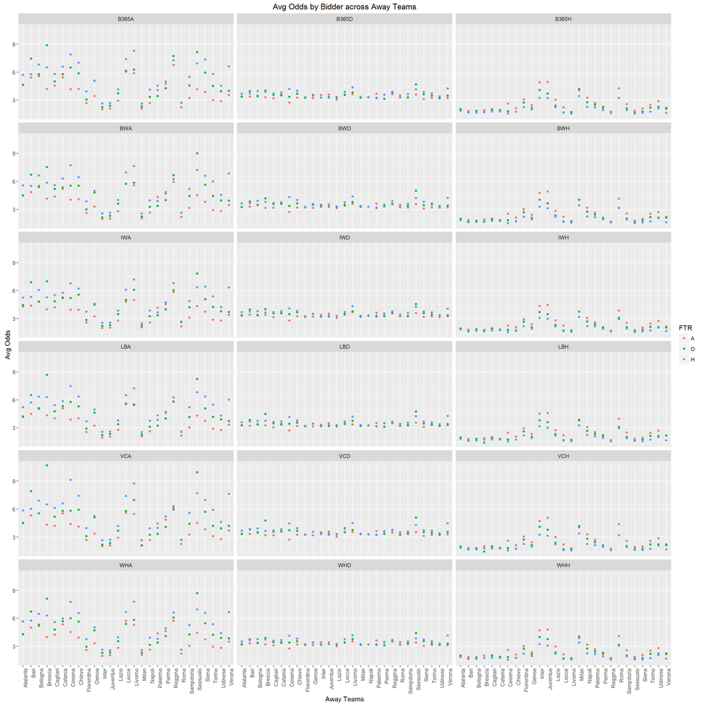

```r
query <- paste("SELECT ", paste('avg(', colnames(data)[6:23], '),', collapse = ""), " AwayTeam, FTR ",
               "FROM data
                GROUP BY AwayTeam, FTR", sep = "")
avg_data <- sqldf(query)
colnames(avg_data) <- c(paste('avg', colnames(data)[6:23], sep = "_"), "AwayTeam", "FTR")
l_avg_data <- alply(avg_data[ ,-c(19, 20)], 2, function(x){
                                                 y <- cbind(x, avg_data[ ,c(19, 20)])
                                                 colnames(y)[1] <- "Avg_Odds"
                                                 return(y)})
n_avg_data <- ldply(l_avg_data, function(x){x})
colnames(n_avg_data)[1] <- "Bid"
n_avg_data[ ,1] <- gsub("avg_", "", n_avg_data[ ,1])
ggplot(n_avg_data, aes(x = AwayTeam, y = Avg_Odds, colour = FTR)) + facet_wrap( ~Bid, nrow = 6, ncol = 3) + geom_point() + theme(axis.text.x = element_text(angle = 90, hjust = 1)) +
xlab('Away Teams') + ylab('Avg Odds') +
ggtitle('Avg Odds by Bidder across Away Teams')
```

This reflects almost mirror results of the above graph away team has low bid value of winning and the teams which have high bid value of winning home have more bid value of winning away game too.

6. Time Analysis

```r
data$Month <- as.factor(month(data$Date))
levels(data$Month) <- c("Jan", "Feb", "Mar", "Apr", "May", "Aug", "Sep", "Oct", "Nov", "Dec")
data$DayofWeek <- as.factor(as.POSIXlt(data$Date)$wday)
data$DayofWeek <- factor(data$DayofWeek, levels(data$DayofWeek)[c(2:7, 1)])
levels(data$DayofWeek) <- c("Mon", "Tue", "Wed", "Thu", "Fri", "Sat", "Sun")
data$DayType <- 'Weekend'
data[data$DayofWeek != 'Sat' & data$DayofWeek != 'Sun', 'DayType'] <- 'Weekday'
```

- Frequency of Games per Month

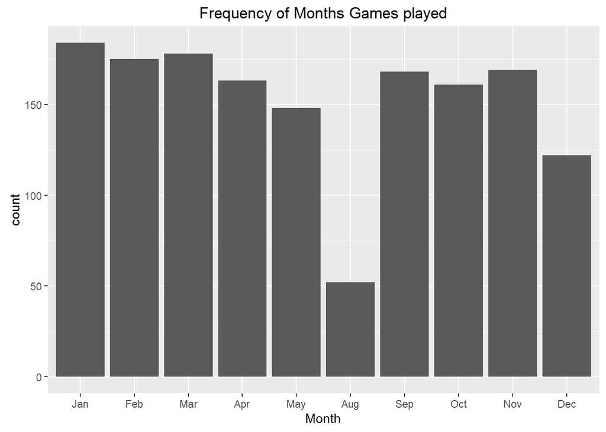

```r
ggplot(data, aes(Month)) + geom_bar() + ggtitle('Frequency of Months Games played')
```

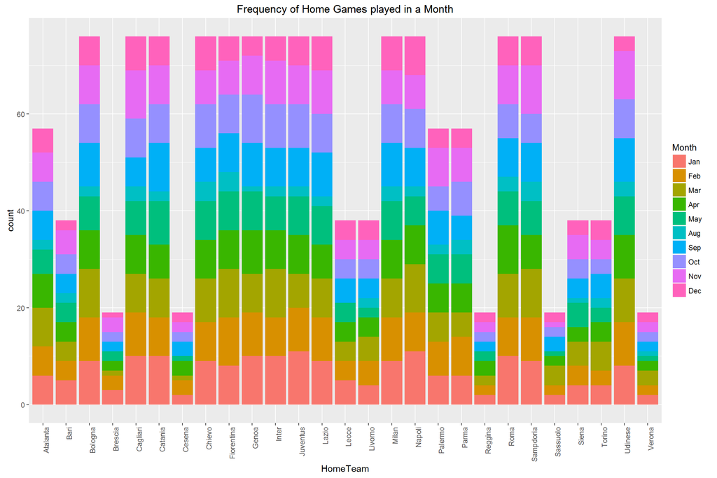

```r
ggplot(data, aes(HomeTeam, fill = Month)) + geom_bar() + ggtitle('Frequency of Home Games played in a Month') + theme(axis.text.x = element_text(angle = 90, hjust = 1))
```

- Games played at Home for a team are spread quite proportionally as per number of games played in total
- Frequency of Away Games per Team in Months

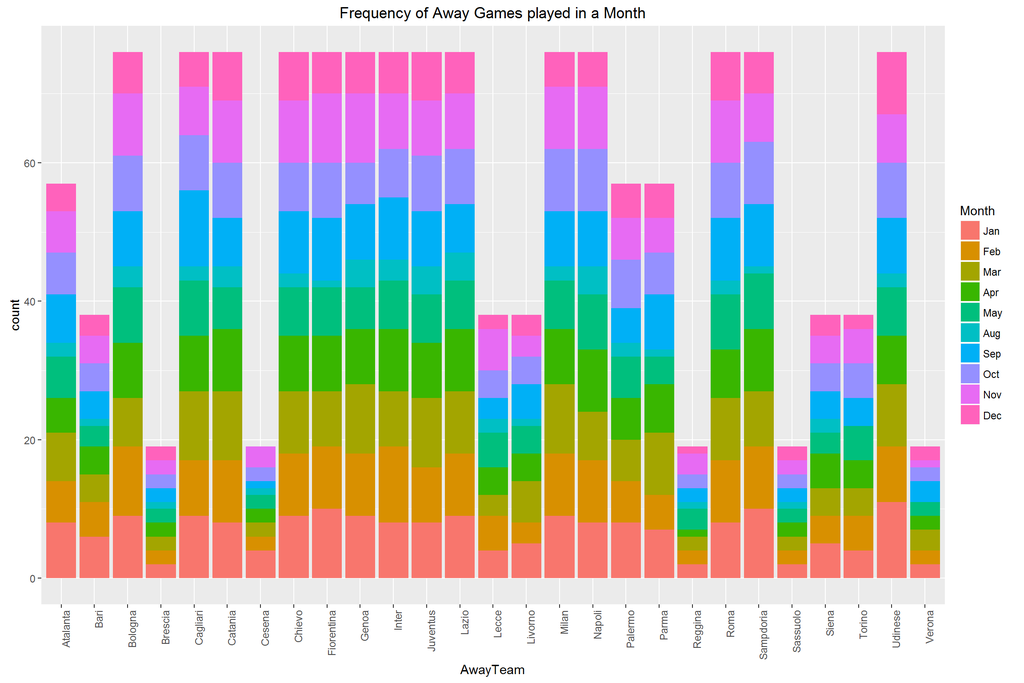

```r
ggplot(data, aes(AwayTeam, fill = Month)) + geom_bar() + ggtitle('Frequency of Away Games played in a Month') + theme(axis.text.x = element_text(angle = 90, hjust = 1))
```

- Games played Away for a team are spread quite proportionally as per number of games played in total
- Average Bidding in Various Months

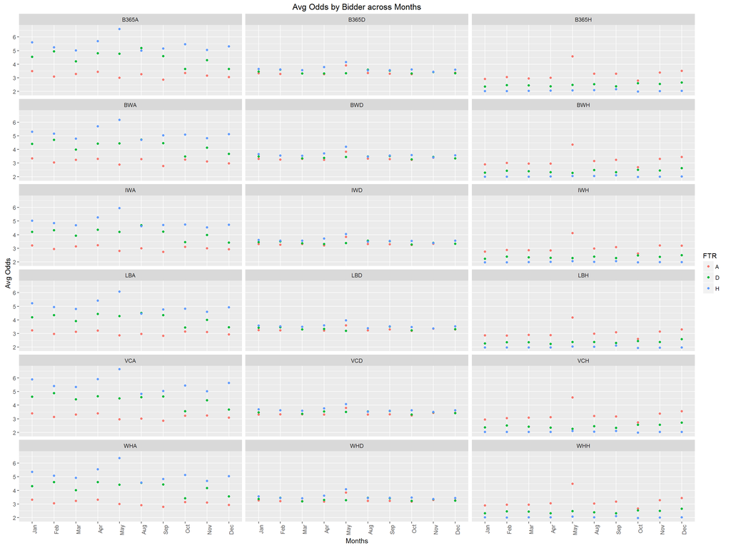

```r
query <- paste("SELECT ", paste('avg(', colnames(data)[6:23], '),', collapse = ""), " Month, FTR ",
               "FROM data
                GROUP BY Month, FTR", sep = "")
avg_data <- sqldf(query)
colnames(avg_data) <- c(paste('avg', colnames(data)[6:23], sep = "_"), "Month", "FTR")
l_avg_data <- alply(avg_data[ ,-c(19, 20)], 2, function(x){
                                                 y <- cbind(x, avg_data[ ,c(19, 20)])
                                                 colnames(y)[1] <- "Avg_Odds"
                                                 return(y)})
n_avg_data <- ldply(l_avg_data, function(x){x})
colnames(n_avg_data)[1] <- "Bid"
n_avg_data[ ,1] <- gsub("avg_", "", n_avg_data[ ,1])
ggplot(n_avg_data, aes(x = Month, y = Avg_Odds, colour = FTR)) + facet_wrap( ~Bid, nrow = 6, ncol = 3) + geom_point() + theme(axis.text.x = element_text(angle = 90, hjust = 1)) +
xlab('Months') + ylab('Avg Odds') +
ggtitle('Avg Odds by Bidder across Months')
```

- For couple of teams in couple of months big is slightly high and low but overall its almost constant across teams in months
- Frequency of Games per Day of Week

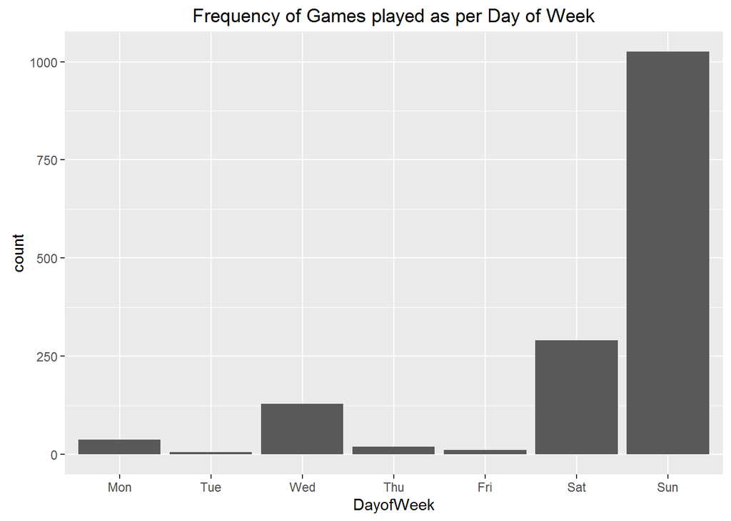

```r
ggplot(data, aes(DayofWeek), order = as.Date(Date)) + geom_bar() + ggtitle('Frequency of Games played as per Day of Week')
```

- Most of the Games are played during mid week, Saturday and Sunday
- Frequency of Home Games per Team as per Day of Week

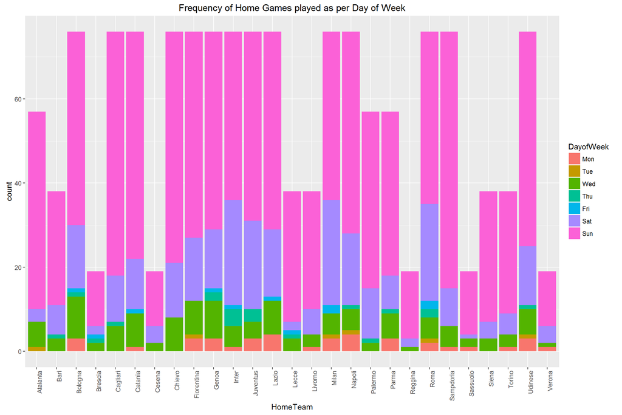

```r
ggplot(data, aes(HomeTeam, fill = DayofWeek)) + geom_bar() + ggtitle('Frequency of Home Games played as per Day of Week') + theme(axis.text.x = element_text(angle = 90, hjust = 1))
```

- Games played at Home for a team on a given Weekday spread quite proportionally as per number of games played in total on that Day of Week
- Frequency of Away Games per Team as per Day of Week

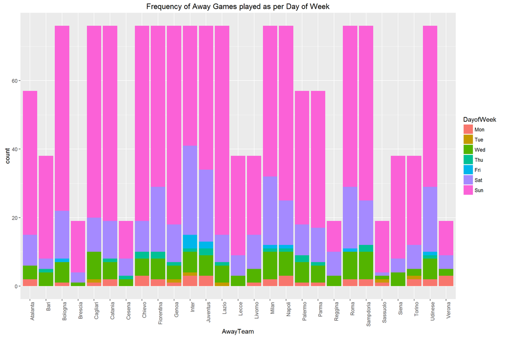

```r
ggplot(data, aes(AwayTeam, fill = DayofWeek)) + geom_bar() + ggtitle('Frequency of Away Games played as per Day of Week') + theme(axis.text.x = element_text(angle = 90, hjust = 1))
```

- Games played at Away for a team on a given Weekday spread quite proportionally as per number of games played in total on that Day of Week
- Average Bidding Across Day of Week

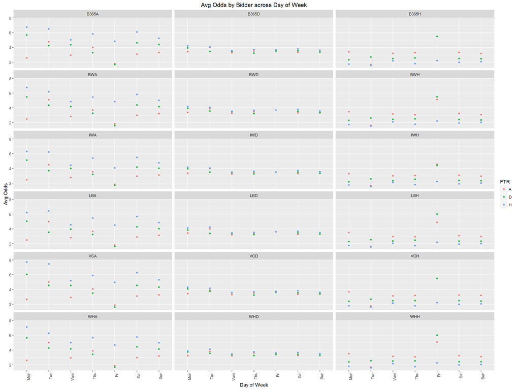

```r
query <- paste("SELECT ", paste('avg(', colnames(data)[6:23], '),', collapse = ""), " DayofWeek, FTR ",
               "FROM data
                GROUP BY DayofWeek, FTR", sep = "")
avg_data <- sqldf(query)
colnames(avg_data) <- c(paste('avg', colnames(data)[6:23], sep = "_"), "DayofWeek", "FTR")
l_avg_data <- alply(avg_data[ ,-c(19, 20)], 2, function(x){
                                                 y <- cbind(x, avg_data[ ,c(19, 20)])
                                                 colnames(y)[1] <- "Avg_Odds"
                                                 return(y)})
n_avg_data <- ldply(l_avg_data, function(x){x})
colnames(n_avg_data)[1] <- "Bid"
n_avg_data[ ,1] <- gsub("avg_", "", n_avg_data[ ,1])
ggplot(n_avg_data, aes(x = DayofWeek, y = Avg_Odds, colour = FTR)) + facet_wrap( ~Bid, nrow = 6, ncol = 3) + geom_point() + theme(axis.text.x = element_text(angle = 90, hjust = 1)) +
xlab('Day of Week') + ylab('Avg Odds') +
ggtitle('Avg Odds by Bidder across Day of Week')
```

### Dummy Variables

First we need to create dummy variables for all the categorical variables like HomeTeam, AwayTeam, Month, DayofWeek and DayType

```r
fac_var <- c("HomeTeam", "AwayTeam", "Month", "DayofWeek", "DayType")

for(var in fac_var){
    data[ ,var] <- as.factor(data[ ,var])
}

dumm_var <- fac_var
final_data <- data[ ,setdiff(colnames(data), c(dumm_var, "ID"))]

for(dumm in dumm_var){
    dumm_data <- model.matrix( ~ data[ ,dumm] - 1, data = data)
    colnames(dumm_data) <- paste(dumm, gsub("data|, dumm|[[:punct:]]", "", colnames(dumm_data)), sep = "_")
    final_data <- cbind(final_data, dumm_data)
}

colnames(final_data) <- gsub(" ", "", colnames(final_data))
final_data$FTR <- as.factor(final_data$FTR)
```

### Missing data - Data Imputation

The bid odds have data missing with 3 for Bet365, 15 for Bet&Win, 16 for InterWetten, 5 for Ladbrokes and 6 for WilliamHill and 19 for VC Bet. We need to impute data for each of them.

```r
for(bet in colnames(final_data)[3:20]){
  missing_bet <- data[(is.na(final_data[ ,bet])), ]
  for(i in 1:dim(missing_bet)[1]){
    x <- data[data$HomeTeam == missing_bet[i, 'HomeTeam'] & data$AwayTeam == missing_bet[i, 'AwayTeam'], ]
    if(dim(x)[1] == 1){
      x <- data[(data$HomeTeam == missing_bet[i, 'HomeTeam'] | data$AwayTeam == missing_bet[i, 'AwayTeam']) & year(data$Date) == year(missing_bet[i, 'Date']), ]
    }
    x$rate <- 1
    x[x[ ,'FTR'] == missing_bet[i, 'FTR'], 'rate'] <- 2
    final_data[which(is.na(data[ ,bet]))[i], bet] <- sum(x$rate * x[ ,bet], na.rm = TRUE)/sum(x$rate, na.rm = TRUE)
  }
}
```

Used other records available for same home team and away team and imputed using weighted mean of the data where data with same result is given twice the weightage compared with other data.

### Near Zero Variance

We need not consider independent variables which do not enough variance in itself. We can use nzv of caret package for this analysis. Following 31 variables have near zero variance and we need not consider them further: HomeTeam_Atalanta, HomeTeam_Bari, HomeTeam_Brescia, HomeTeam_Cesena, HomeTeam_Lecce, HomeTeam_Livorno, HomeTeam_Palermo, HomeTeam_Parma, HomeTeam_Reggina, HomeTeam_Sassuolo, HomeTeam_Siena, HomeTeam_Torino, HomeTeam_Verona, AwayTeam_Atalanta, AwayTeam_Bari, AwayTeam_Brescia, AwayTeam_Cesena, AwayTeam_Lecce, AwayTeam_Livorno, AwayTeam_Palermo, AwayTeam_Parma, AwayTeam_Reggina, AwayTeam_Sassuolo, AwayTeam_Siena, AwayTeam_Torino, AwayTeam_Verona, Month_Aug, DayofWeek_Mon, DayofWeek_Tue, DayofWeek_Thu, DayofWeek_Fri

```r
nzv_var <- nzv(final_data)
final_data <- final_data[ ,-nzv_var]
```

### Creating Train and Test Samples

```r
train <- final_data[year(final_data$Date) < 2013, -1]
test <- final_data[year(final_data$Date) >= 2013, -1]
```

- Size of train data set is **1140** and test data set is **380**

#### Outlier Removal

```r
train <- train[train[ ,'B365H'] < (mean(train[ ,'B365H']) + 2.58 * sd(train[ ,'B365H'])) &
               train[ ,'B365H'] > (mean(train[ ,'B365H']) - 2.58 * sd(train[ ,'B365H'])) &
               train[ ,'B365D'] < (mean(train[ ,'B365D']) + 2.58 * sd(train[ ,'B365D'])) &
               train[ ,'B365D'] > (mean(train[ ,'B365D']) - 2.58 * sd(train[ ,'B365D'])) &
               train[ ,'B365A'] < (mean(train[ ,'B365A']) + 2.58 * sd(train[ ,'B365A'])) &
               train[ ,'B365A'] > (mean(train[ ,'B365A']) - 2.58 * sd(train[ ,'B365A'])) &
               train[ ,'BWH'] < (mean(train[ ,'BWH']) + 2.58 * sd(train[ ,'BWH'])) &
               train[ ,'BWH'] > (mean(train[ ,'BWH']) - 2.58 * sd(train[ ,'BWH'])) &
               train[ ,'BWD'] < (mean(train[ ,'BWD']) + 2.58 * sd(train[ ,'BWD'])) &
               train[ ,'BWD'] > (mean(train[ ,'BWD']) - 2.58 * sd(train[ ,'BWD'])) &
               train[ ,'BWA'] < (mean(train[ ,'BWA']) + 2.58 * sd(train[ ,'BWA'])) &
               train[ ,'BWA'] > (mean(train[ ,'BWA']) - 2.58 * sd(train[ ,'BWA'])) &
               train[ ,'IWH'] < (mean(train[ ,'IWH']) + 2.58 * sd(train[ ,'IWH'])) &
               train[ ,'IWH'] > (mean(train[ ,'IWH']) - 2.58 * sd(train[ ,'IWH'])) &
               train[ ,'IWD'] < (mean(train[ ,'IWD']) + 2.58 * sd(train[ ,'IWD'])) &
               train[ ,'IWD'] > (mean(train[ ,'IWD']) - 2.58 * sd(train[ ,'IWD'])) &
               train[ ,'IWA'] < (mean(train[ ,'IWA']) + 2.58 * sd(train[ ,'IWA'])) &
               train[ ,'IWA'] > (mean(train[ ,'IWA']) - 2.58 * sd(train[ ,'IWA'])) &
               train[ ,'LBH'] < (mean(train[ ,'LBH']) + 2.58 * sd(train[ ,'LBH'])) &
               train[ ,'LBH'] > (mean(train[ ,'LBH']) - 2.58 * sd(train[ ,'LBH'])) &
               train[ ,'LBD'] < (mean(train[ ,'LBD']) + 2.58 * sd(train[ ,'LBD'])) &
               train[ ,'LBD'] > (mean(train[ ,'LBD']) - 2.58 * sd(train[ ,'LBD'])) &
               train[ ,'LBA'] < (mean(train[ ,'LBA']) + 2.58 * sd(train[ ,'LBA'])) &
               train[ ,'LBA'] > (mean(train[ ,'LBA']) - 2.58 * sd(train[ ,'LBA'])) &
               train[ ,'WHH'] < (mean(train[ ,'WHH']) + 2.58 * sd(train[ ,'WHH'])) &
               train[ ,'WHH'] > (mean(train[ ,'WHH']) - 2.58 * sd(train[ ,'WHH'])) &
               train[ ,'WHD'] < (mean(train[ ,'WHD']) + 2.58 * sd(train[ ,'WHD'])) &
               train[ ,'WHD'] > (mean(train[ ,'WHD']) - 2.58 * sd(train[ ,'WHD'])) &
               train[ ,'WHA'] < (mean(train[ ,'WHA']) + 2.58 * sd(train[ ,'WHA'])) &
               train[ ,'WHA'] > (mean(train[ ,'WHA']) - 2.58 * sd(train[ ,'WHA'])) &
               train[ ,'VCH'] < (mean(train[ ,'VCH']) + 2.58 * sd(train[ ,'VCH'])) &
               train[ ,'VCH'] > (mean(train[ ,'VCH']) - 2.58 * sd(train[ ,'VCH'])) &
               train[ ,'VCD'] < (mean(train[ ,'VCD']) + 2.58 * sd(train[ ,'VCD'])) &
               train[ ,'VCD'] > (mean(train[ ,'VCD']) - 2.58 * sd(train[ ,'VCD'])) &
               train[ ,'VCA'] < (mean(train[ ,'VCA']) + 2.58 * sd(train[ ,'VCA'])) &
               train[ ,'VCA'] > (mean(train[ ,'VCA']) - 2.58 * sd(train[ ,'VCA'])), ]
```

### Correlation

Final check we need to do is correlation among the independent continuous variables. If they have high correlation then we may use Principal Component Analysis or Factor Analysis. There are 45 correlations that have more than 0.8 value, indicating very high correlation in the continuous independent variable. Need to normalize the data before performing factor analysis

```r
train_mean <- apply(train[ ,c(2:19)], 2, mean)
train_sd <- apply(train[ ,c(2:19)], 2, sd)
for(i in 2:19){
  train[ ,i] <- (train[ ,i] - train_mean[i-1])/train_sd[i-1]
  test[ ,i] <- (test[ ,i] - train_mean[i-1])/train_sd[i-1]
}

fit <- principal(train[ ,c(2:19)], nfactors=18, rotate="varimax")
fit$loadings
```

```
##
## Loadings:
##       PC1    PC2    PC3    PC4    PC6    PC8    PC7    PC5    PC9
## B365H  0.965 -0.210 -0.111
## B365D -0.231  0.927  0.185        -0.102        -0.134 -0.122
## B365A -0.637  0.567  0.510
## BWH    0.965 -0.191 -0.135
## BWD   -0.191  0.932  0.151                       0.252
## BWA   -0.638  0.596  0.461
## IWH    0.945 -0.244 -0.129
## IWD   -0.217  0.886  0.118  0.390
## IWA   -0.630  0.581  0.451  0.129                              0.210
## LBH    0.955 -0.214 -0.124
## LBD   -0.222  0.899                0.363
## LBA   -0.614  0.605  0.476
## WHH    0.960 -0.219 -0.122
## WHD   -0.207  0.935                                     0.249
## WHA   -0.621  0.609  0.467
## VCH    0.964 -0.165 -0.154
## VCD   -0.204  0.902  0.160                0.340
## VCA   -0.616  0.626  0.425
##       PC10   PC13   PC15   PC11   PC14   PC12   PC17   PC16   PC18
## B365H
## B365D
## B365A
## BWH
## BWD
## BWA                                       0.151
## IWH          -0.166
## IWD
## IWA
## LBH                        -0.155
## LBD
## LBA                  0.160
## WHH                                                    -0.117
## WHD
## WHA                                0.148
## VCH                                             -0.121
## VCD
## VCA    0.194
##
##                  PC1   PC2   PC3   PC4   PC6   PC8   PC7   PC5   PC9  PC10
## SS loadings    8.140 7.411 1.518 0.179 0.153 0.142 0.088 0.083 0.049 0.040
## Proportion Var 0.452 0.412 0.084 0.010 0.009 0.008 0.005 0.005 0.003 0.002
## Cumulative Var 0.452 0.864 0.948 0.958 0.967 0.975 0.980 0.984 0.987 0.989
##                 PC13  PC15  PC11  PC14  PC12  PC17  PC16  PC18
## SS loadings    0.033 0.032 0.029 0.026 0.026 0.018 0.018 0.014
## Proportion Var 0.002 0.002 0.002 0.001 0.001 0.001 0.001 0.001
## Cumulative Var 0.991 0.993 0.994 0.996 0.997 0.998 0.999 1.000
```

The first three principal components explain the variance present in all the 18 variables. First factor describes preference of home team winning against draw or losing (all the home bids have high positive value, while draw and away have low values), second factor shows home team not winning against draw or losing (home bids have negative value, while draw or away have high positive values), third factor shows preference for draw or away team winning (only draw and away have mostly positive values). We can define these components as StrongHome, StrongDrawWeakAway and WeakDrawStrongAway.

```r
train[ ,c('StrongHome', 'StrongDrawWeakAway', 'WeakDrawStrongAway')] <- data.matrix(train[ ,c(2:19)]) %*% data.matrix(fit$loadings[ ,c('PC1', 'PC2', 'PC3')])
test[ ,c('StrongHome', 'StrongDrawWeakAway', 'WeakDrawStrongAway')] <- data.matrix(test[ ,c(2:19)]) %*% data.matrix(fit$loadings[ ,c('PC1', 'PC2', 'PC3')])

train <- train[ ,-c(2:19)]
test <- test[ ,-c(2:19)]
```

### Collinearity Diagnostics

Before moving to modeling, we need to make sure that none of our independent variables have a collinearity among themselves. One way to ensure this is using the [Variance Influence Factor](https://onlinecourses.science.psu.edu/stat501/node/347). In general any value greater than 10 is considered high collinearity. *(Note: Source for below [vif_func](http://stats.stackexchange.com/questions/87278/finding-the-best-linear-model-for-each-response-variable-in-multivariate-multipl) function).*

```r
vif_func <- function(in_frame, thresh=10, trace=T){
    #get initial vif value for all comparisons of variables
    vif_init<-NULL
    var_names <- names(in_frame)
    for(val in var_names){
        regressors <- var_names[-which(var_names == val)]
        form <- paste(regressors, collapse = '+')
        form_in <- formula(paste(val, '~', form))
        vif_init<-rbind(vif_init, c(val, VIF(lm(form_in, data = in_frame))))
    }
    vif_init <- vif_init[!is.nan(as.numeric(vif_init[ ,2])), ]
    vif_max<-max(as.numeric(vif_init[,2]))
    if(vif_max >= thresh){
        in_dat<-in_frame
        #backwards selection of explanatory variables, stops when all VIF values are below 'thresh'
        while(vif_max >= thresh){
            vif_vals<-NULL
            var_names <- names(in_dat)
            for(val in var_names){
                regressors <- var_names[-which(var_names == val)]
                form <- paste(regressors, collapse = '+')
                form_in <- formula(paste(val, '~', form))
                vif_add<-VIF(lm(form_in, data = in_dat))
                vif_vals<-rbind(vif_vals,c(val,vif_add))
            }
            max_row<-which(vif_vals[,2] == max(as.numeric(vif_vals[,2])))[1]
            vif_vals <- vif_vals[!is.nan(as.numeric(vif_vals[ ,2])), ]
            vif_max<-as.numeric(vif_vals[max_row,2])
            if(vif_max<thresh) break
            in_dat<-in_dat[,!names(in_dat) %in% vif_vals[max_row,1]]

        }
    return(names(in_dat))
    }
}

final_vars <- vif_func(in_frame = train[ ,-1])
```

4 independent variables DayofWeek_Sat, DayType_Weekday, StrongHome, WeakDrawStrongAway that were found to have high collinearity.

```r
train <- train[ ,c('FTR', final_vars)]
test <- test[ ,c('FTR', final_vars)]
```